# workshop_5

Quentin Le Roux

11/17/2020

# Exercise 1

1. Download the dataset and show the summary.

```
## [1] "data.frame"
```

```
##  fixed.acidity   volatile.acidity  citric.acid    residual.sugar
##  Min.   : 4.60   Min.   :0.1200   Min.   :0.000   Min.   : 0.900
##  1st Qu.: 7.10   1st Qu.:0.3900   1st Qu.:0.090   1st Qu.: 1.900
##  Median : 7.90   Median :0.5200   Median :0.260   Median : 2.200
##  Mean   : 8.32   Mean   :0.5278   Mean   :0.271   Mean   : 2.539
##  3rd Qu.: 9.20   3rd Qu.:0.6400   3rd Qu.:0.420   3rd Qu.: 2.600
##  Max.   :15.90   Max.   :1.5800   Max.   :1.000   Max.   :15.500
##    chlorides       free.sulfur.dioxide total.sulfur.dioxide    density
##  Min.   :0.01200   Min.   : 1.00       Min.   :  6.00       Min.   :0.9901
##  1st Qu.:0.07000   1st Qu.: 7.00       1st Qu.: 22.00       1st Qu.:0.9956
##  Median :0.07900   Median :14.00       Median : 38.00       Median :0.9968
##  Mean   :0.08747   Mean   :15.87       Mean   : 46.47       Mean   :0.9967
##  3rd Qu.:0.09000   3rd Qu.:21.00       3rd Qu.: 62.00       3rd Qu.:0.9978
##  Max.   :0.61100   Max.   :72.00       Max.   :289.00       Max.   :1.0037
##        pH          sulphates         alcohol         quality
##  Min.   :2.740   Min.   :0.3300   Min.   : 8.40   Min.   :3.000
##  1st Qu.:3.210   1st Qu.:0.5500   1st Qu.: 9.50   1st Qu.:5.000
##  Median :3.310   Median :0.6200   Median :10.20   Median :6.000
##  Mean   :3.311   Mean   :0.6581   Mean   :10.42   Mean   :5.636
##  3rd Qu.:3.400   3rd Qu.:0.7300   3rd Qu.:11.10   3rd Qu.:6.000
##  Max.   :4.010   Max.   :2.0000   Max.   :14.90   Max.   :8.000
```

2. Add the variable “label” for alcohol percentage (alcohol variable) to group the alcohol concentration in the following way:

Light < 9; 9 ≤ Medium < 12 ; Strong ≥ 12

```r
data$label = ""
data$label[data$alcohol<9]="Light"
data$label[9<=data$alcohol & data$alcohol<12]="Medium"
data$label[data$alcohol>=12]="Strong"
```

3. How many Light, Medium and Strong wines there are in the dataset?

```
##
##  Light Medium Strong
##      7   1430    162
```

4. Create a barplot for the 3 levels variable “label” where the color of bars depends on the level of the alcohol concentration, with title: “Alcohol concentration”

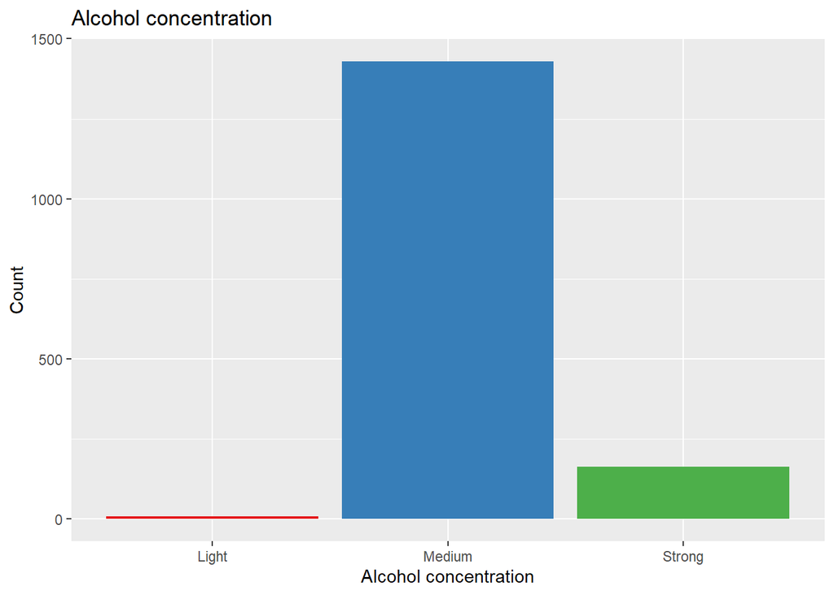

5. Show histograms for fixed.acidity by label

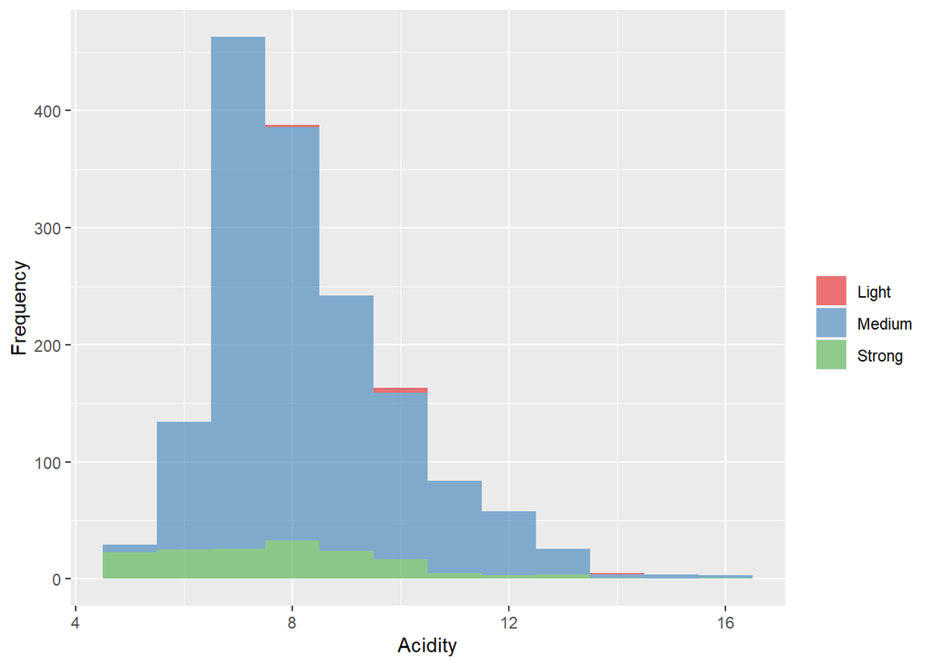

6. Create a density plot taking into account the citric.acid for the three level of the variable “label”

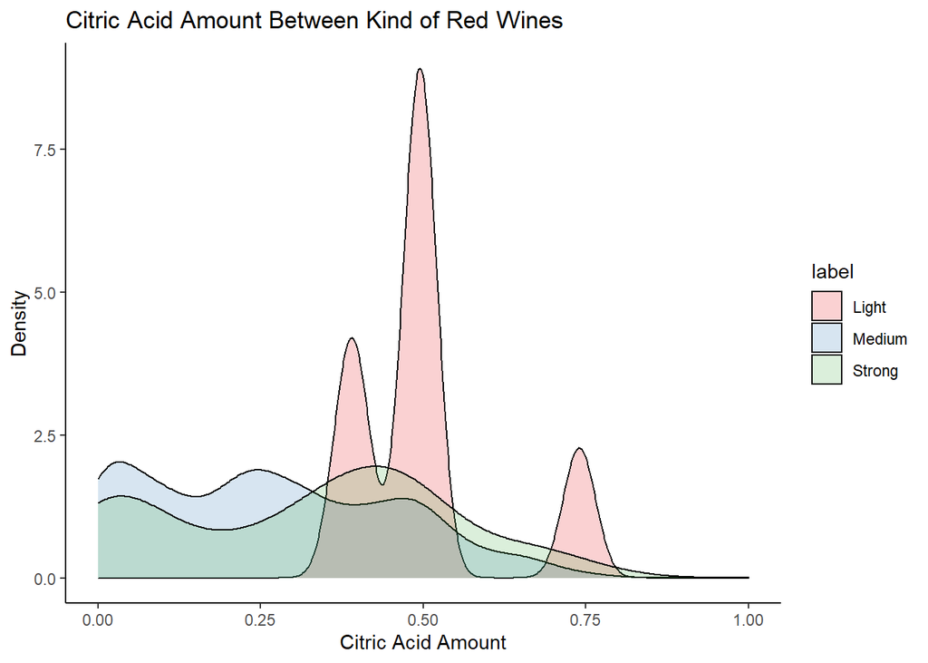

7. Create a boxplot for the overall dataset (Consider the Log Scale)

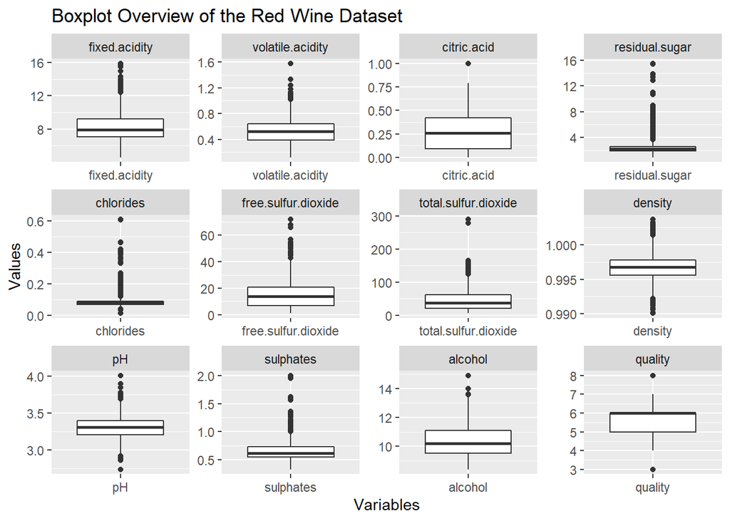

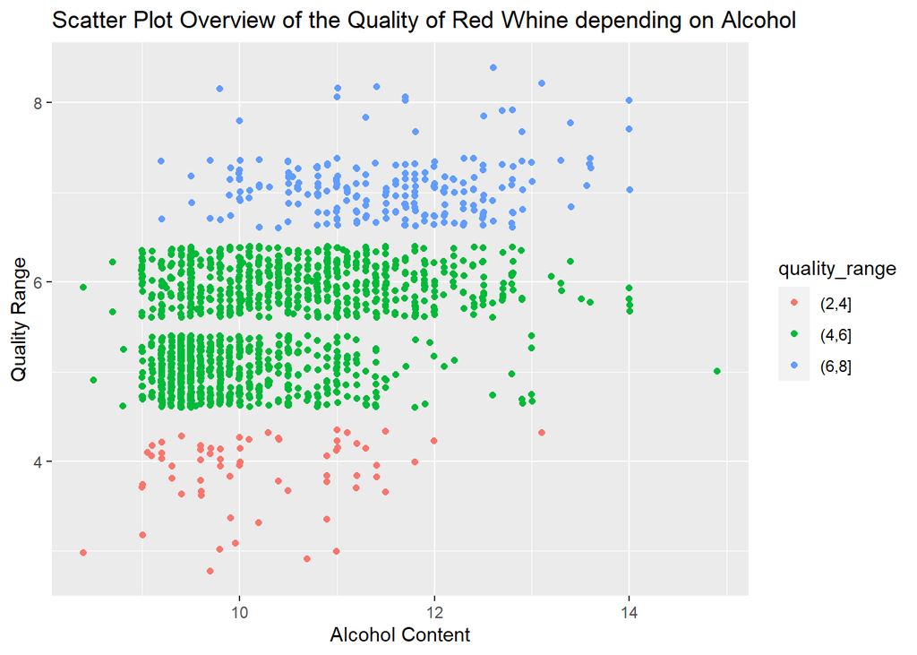

# Exercise 2

1. Load the dataset gapminder from the package gapminder
2. Create a tibble 5×4 containing the number of observation per continent, the number of countries per continent and the average of life expectation.

```
## # A tibble: 5 x 4
##   continent observations number_countries average_lifespan
##   <fct>            <int>            <int>            <dbl>
## 1 Africa             624               52             48.9
## 2 Americas           300               25             64.7
## 3 Asia               396               33             60.1
## 4 Europe             360               30             71.9
## 5 Oceania             24                2             74.3
```

3. Show the columns of country, year, lifeExp and add a variable that represents the year of life expectancy gained with respect to 1957, for each country, until 1963.

```
## # A tibble: 142 x 4
## # Groups:   country [142]
##    country      year lifeExp year_gain
##    <fct>       <int>   <dbl>     <dbl>
##  1 Afghanistan  1962    32.0     1.66
##  2 Albania      1962    64.8     5.54
##  3 Algeria      1962    48.3     2.62
##  4 Angola       1962    34       2.00
##  5 Argentina    1962    65.1     0.743
##  6 Australia    1962    70.9     0.6
##  7 Austria      1962    69.5     2.06
##  8 Bahrain      1962    56.9     3.09
##  9 Bangladesh   1962    41.2     1.87
## 10 Belgium      1962    70.2     1.01
## # ... with 132 more rows
```

```
## [1] "The most populous country was :"
```

```
## # A tibble: 1 x 2
##   country        pop
##   <fct>        <int>
## 1 China   1164970000
```

```
## # A tibble: 142 x 2
##    country             pop
##    <fct>             <dbl>
##  1 China         10990283.
##  2 India          8226415.
##  3 United States  2423530.
##  4 Indonesia      1743547.
##  5 Brazil         1471471.
##  6 Japan          1172918.
##  7 Pakistan       1132689.
##  8 Bangladesh     1072685.
##  9 Nigeria         880795.
## 10 Mexico          831236.
## # ... with 132 more rows
```